# Monday, October 19th, 2026

Last week, we discussed visualizing $2$D-arrays and $3$D-arrays where the third dimension stores RGB(A) values.

## [Project 3: Tartans](https://jllottes.github.io/Projects/tartans/tartans.html)

Let's get started working with tartans by generating vertical and horizontal stripes for the following pattern (see project page for details):

Pattern :

> B14 K6 B6 K6 B6 K32 OG32

where the colors B, K, and OG are given by the RGB triples:

> B : [52, 80, 100]  
> K : [16, 16, 16]  
> OG : [92, 100, 40]

To get started, we'll need to initialize an array with the correct shape. What is the total width of this pattern?

```python
import numpy as np
import matplotlib.pyplot as plt
```

```python
14 + 6 + 6 + 6 + 6 + 32 + 32
```

```
102
```

```python
vertical_stripes = np.zeros((102, 102, 3))  # 3D array with the third dimension storing RGB values
```

```python
vertical_stripes
```

```
array([[[0., 0., 0.],
        [0., 0., 0.],
        [0., 0., 0.],
        ...,
        [0., 0., 0.],
        [0., 0., 0.],
        [0., 0., 0.]],

       [[0., 0., 0.],
        [0., 0., 0.],
        [0., 0., 0.],
        ...,
        [0., 0., 0.],
        [0., 0., 0.],
        [0., 0., 0.]],

       [[0., 0., 0.],
        [0., 0., 0.],
        [0., 0., 0.],
        ...,
        [0., 0., 0.],
        [0., 0., 0.],
        [0., 0., 0.]],

       ...,

       [[0., 0., 0.],
        [0., 0., 0.],
        [0., 0., 0.],
        ...,
        [0., 0., 0.],
        [0., 0., 0.],
        [0., 0., 0.]],

       [[0., 0., 0.],
        [0., 0., 0.],
        [0., 0., 0.],
        ...,
        [0., 0., 0.],
        [0., 0., 0.],
        [0., 0., 0.]],

       [[0., 0., 0.],
        [0., 0., 0.],
        [0., 0., 0.],
        ...,
        [0., 0., 0.],
        [0., 0., 0.],
        [0., 0., 0.]]])
```

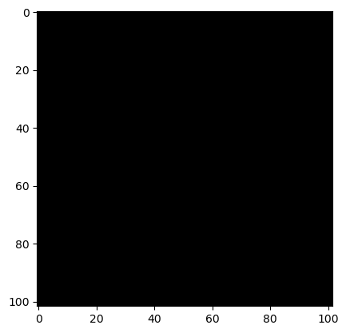

```python
plt.imshow(vertical_stripes)
```

Right now, our array is a pure black picture. Let's add the first vertical stripe, which has color B = [52, 80, 100] and has width 14.

```python
vertical_stripes[:, 0:14] = [50/255, 80/255, 100/255]
```

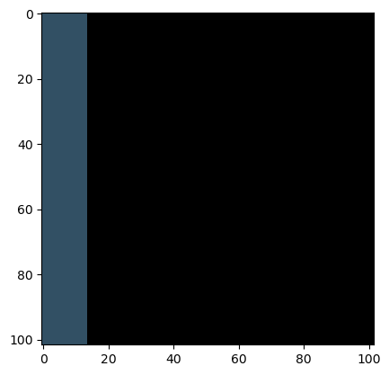

```python
plt.imshow(vertical_stripes)
```

**Exercise:** Add the remaining stripes from the sample pattern to the `vertical_stripes` array.

Pattern :

> B14 K6 B6 K6 B6 K32 OG32

where the colors B, K, and OG are given by the RGB triples:

> B : [52, 80, 100]  
> K : [16, 16, 16]  
> OG : [92, 100, 40]

```python
vertical_stripes[:, 0:14] = [52/255, 80/255, 100/255]
vertical_stripes[:,14:20] = [16/255, 16/255, 16/255]
vertical_stripes[:,20:26] = [52/255, 80/255, 100/255]
vertical_stripes[:,26:32] = [16/255, 16/255, 16/255]
vertical_stripes[:,32:38] = [52/255, 80/255, 100/255]
vertical_stripes[:,38:70] = [16/255, 16/255, 16/255]
vertical_stripes[:,70:102] = [92/255, 100/255, 40/255]
```

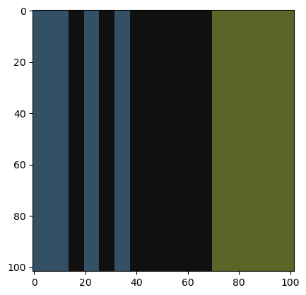

```python
plt.imshow(vertical_stripes)
```

Some thoughts:

- We need a better way to generate this vertical stripes array. There was far too much manual typing/calculation to add each stripe. We'll come back and address this shortly.
- Now that we have an array of vertical stripes, we can easily generate an array of horizontal stripes. This can be done transposing our array (see below).
- Once we have vertical and horizontal stripes, we need to super-impose them somehow to generate the tartan pattern.

### Array transposes

For a 2-dimensional matrix, the transpose flips rows and columns. That is, the first row becomes the first column, the second row becomes the second column, etc. In Python, we can use the `.T` method on a 2D array to get its transpose.

```python
A = np.arange(50).reshape(5,10)
```

```python
print(A)
```

```
[[ 0  1  2  3  4  5  6  7  8  9]
 [10 11 12 13 14 15 16 17 18 19]
 [20 21 22 23 24 25 26 27 28 29]
 [30 31 32 33 34 35 36 37 38 39]
 [40 41 42 43 44 45 46 47 48 49]]
```

```python
print(A.T)
```

```
[[ 0 10 20 30 40]
 [ 1 11 21 31 41]
 [ 2 12 22 32 42]
 [ 3 13 23 33 43]
 [ 4 14 24 34 44]
 [ 5 15 25 35 45]
 [ 6 16 26 36 46]
 [ 7 17 27 37 47]
 [ 8 18 28 38 48]
 [ 9 19 29 39 49]]
```

```python
print(A.shape)
print(A.T.shape)
```

```
(5, 10)
(10, 5)
```

We would like to take the transpose of our `vertical_stripes` array so that the columns of `vertical_stripes` become the rows of `horizontal_stripes`. In other words, the vertical stripes will become horizontal stripes.

*Problem:* The `vertical_stripes` array is a 3-dimensional array (rows, columns, color channels). What does `vertical_stripes.T` give us in this case?

```python
vertical_stripes.shape
```

```
(102, 102, 3)
```

```python
vertical_stripes.T.shape
```

```
(3, 102, 102)
```

```python
#plt.imshow(vertical_stripes.T)
```

It turns out that the `.T` attribute reverses the order of the axes. That is, the first axis (rows) becomes the last axis, the second axis (columns) becomes the second-last axis, etc. In the case of the `vertical_stripes` array, the color channel axis became the row axis, the column axis remained as the column axis, and the row axis became the color channel axis. For our needs, this is not useful. Instead, we just want to swap the row and column axes.

We can use the `np.transpose` function to do more targeted transposing.

```python
#help(np.transpose)
```

When calling `np.transpose`, we can optionally supply a keyword argument `axes` which gives a permutation of the axes of the array. In particular, using `axes = [1, 0, 2]` will give a transposed matrix where:

- the old axis `1` (i.e. the columns) becomes the new axis `0` (i.e. the rows),
- the old axis `0` becomes the new axis `1`, and
- the old axis `2` (i.e. the color channel) remains as axis `2`.

Let's use this to define the `horizontal_stripes` array.

```python
horizontal_stripes = np.transpose(vertical_stripes, axes=[1, 0, 2])
```

```python
print(horizontal_stripes.shape)
```

```
(102, 102, 3)
```

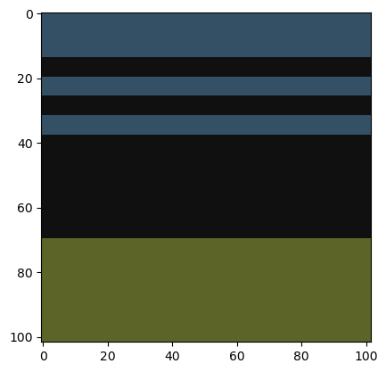

```python
plt.imshow(horizontal_stripes)
```

### Creating a tartan from vertical and horizontal arrays

We now have vertical and horizontal stripes. How can we combine them to get a tartan pattern?

One simple idea is to take the average of the horizontal and vertical stripe arrays.

```python
avg_tartan = (vertical_stripes + horizontal_stripes) / 2
```

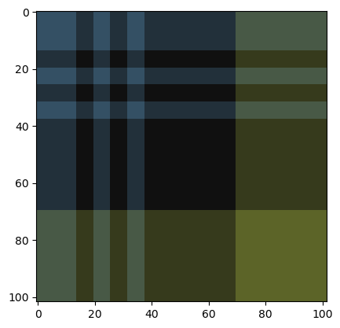

```python
plt.imshow(avg_tartan)
```

This gives flat colors rather than an interleaved combination. Can we instead generate a checkerboard pattern to interleave these stripes? To do so, we want to go row by row, column by column, and alternatingly select a color from the `vertical_stripes` and `horizontal_stripes` arrays.

**Exercise:** Create a `checkerboard_tartan` array that combines the `vertical_stripes` and `horizontal_stripes` arrays in checkerboard pattern.

# In-class exercise

```python
checkerboard_tartan = np.zeros((102, 102, 3))

for row in range(102):       # Iterate row by row
    for col in range(102):   # Iterate column by column
        if ...:
            if ...:
                checkerboard_tartan[row,col] = vertical_stripes[row, col]
            else:
                checkerboard_tartan[row,col] = horizontal_stripes[row, col]
        else:
            if ...:
                checkerboard_tartan[row,col] = vertical_stripes[row, col]
            else:
                checkerboard_tartan[row,col] = horizontal_stripes[row, col]
```

```python
fig = plt.figure(figsize=(10,10), dpi=200)
```

[output not shown]

Where to go from here:

- We need a better way of generating the `vertical_stripes` array.
- We need to generate the more authentic tartan pattern described in the project page.
- We need to pad our tartan pattern to be `500` by `500` rows/columns.